# eARThKids survey report - April 2018

# Introduction

The external evaluation of eARThKids by MN Associates, Inc. examines to what extent the various strategies and activities of the project have led to the intended programmatic outcomes. The main sources of data collection are: document reviews, meeting notes, teacher and teaching artists surveys, students’ demographics and attendance data, and pre-and-post student assessments using data from the Directed Reading Assessments.

The eARThKids evaluation is based on the following evaluation questions:

**Program Implementation**

1. To what extent are the participating schools implementing the eARThKids model as designed and envisioned by the Young Audiences and PG County Public Schools?
2. To what extent do participating teachers find eARThKids to be effective in (a) successfully improving their instructional practices through co-teaching and professional development?

**Program Impact**

1. To what extent has the eARThKids out-of-school-time program assisted students in meeting academic requirements on grade level?

This short survey summary report was generated from data collected from the classroom teachers and teaching artists for the eARThKids program has been completed by MN Associates, Inc.

# Overall Satisfaction

Question asked: Based on your experience as a classroom teacher/teaching artist in the eARThKids program, please rate the degree to which you agree to the following statements that speak to your knowledge and satisfaction with the program:

Disagree Agree Strongly agree

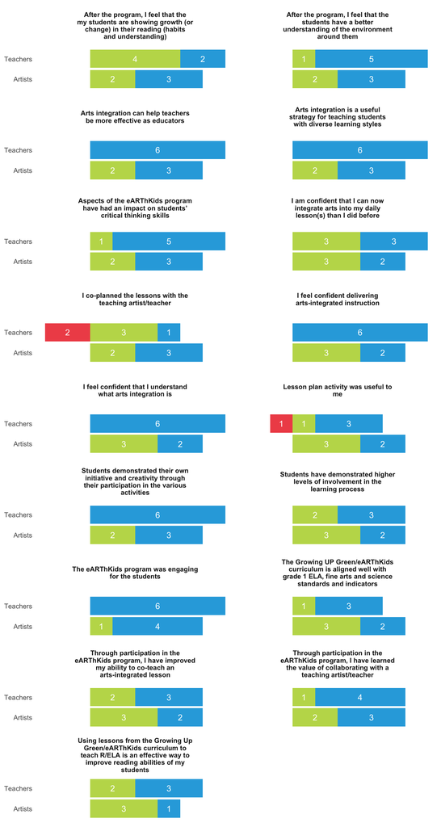

# Learning

Question asked to teaching artists: I feel that the teacher(s) I worked with can…  
Question asked to teachers: I can…

Disagree Agree Strongly agree

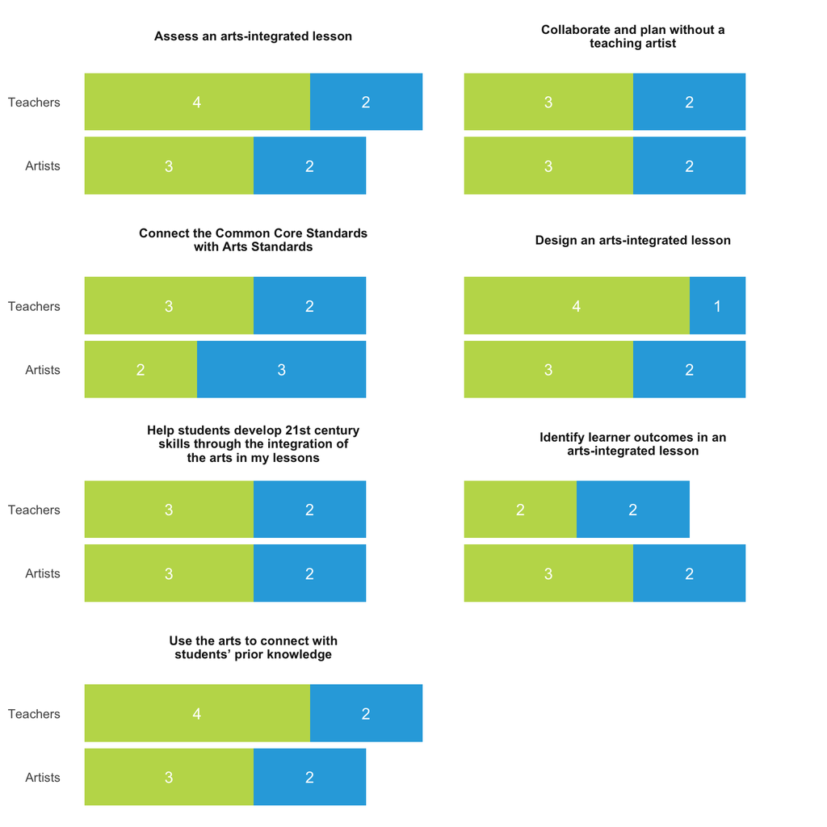

# Professional Development

Disagree Agree Strongly agree

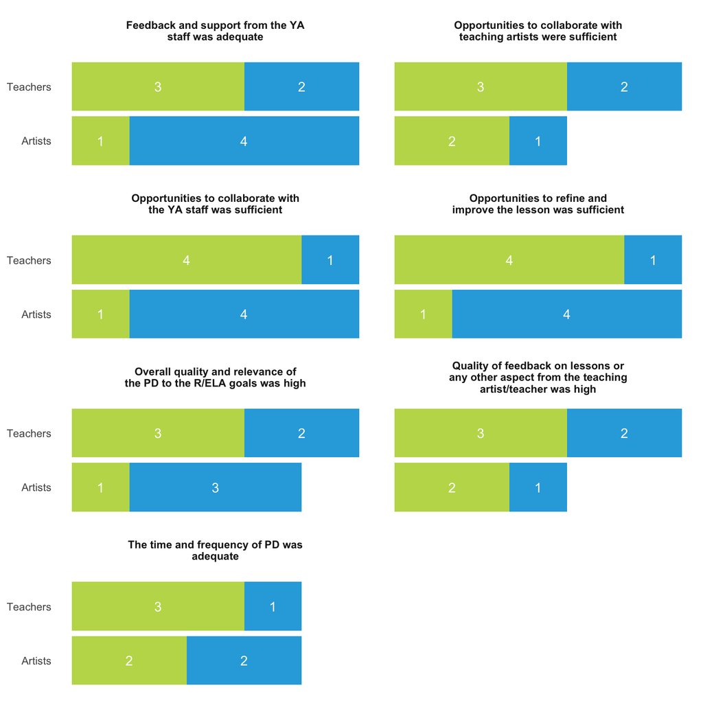

# Open-Ended Responses (Teaching Artists)

[output not shown]

| What did you like the most about the program overall: |
| --- |
| The student response, the teachers’ creativity. |
| I enjoyed the challenge of connecting my art form to Environmental Literacy. I also enjoyed using basic rhythm patterns and steady beat on the body to teach site words. |
| It was far better structured than typical after-school programs. The students were engaged and focused. |
| The Children were very enthused during the entire process. |
| Getting kids excited about environmentalism and art at the same time! |
| The consistency of working with the same kids, the environmental connection |

[output not shown]

[output not shown]

[output not shown]

| Any additional comments: |
| --- |
| Wish we could do it again. |
| I think that teachers were often new to arts integration, so it was a valuable experience for them to see how as new AI lesson works. |
| Had a challenging, but successful time at all three schools. Would prefer a residency during school time. |

# Open-Ended Responses (Teachers)

[output not shown]

| What did you like the most about the program overall: |
| --- |
| The opportunity to explore different art forms. |
| The students were very well engaged during the program. They loved performing during the Arts integrated piece. It was learning through the Arts. |
| The students learning about composting in many ways and how to take care of the environment: hip hop, tap dance, visual presentations, making of projects |
| The hands-on activities that allowed students’ maximum participation and learning. |

[output not shown]

[output not shown]

[output not shown]

| How can the program be improved in the future? |
| --- |
| At the end of each period we can have a celebration and give the students a certificate for attending. |
| The type of dismissal the school has for the kids, that will matter as to the staff who needs to stay until dismissal time ( William Paca has car riders and bus dismissal.) |
| More reading resources specifically about the environment that the students may read and require them to analyze the story and look for key details in the text. |

| Any additional comments: |
| --- |
| I really enjoyed this program since I realized how the students can benefit. |
| The program is a great opportunity for the kids to learn how to take care of the environment at their young age and at the same time integrate and enhance their reading skills through the art. |
| The program has helped the students to be better listeners and participants in the teaching - learning process. |